# Impact of Severe Weather Events on Public Health and Economy in the US

Stas Prihodco

Wednesday, April 15, 2015

# Synopsis

Storms and other severe weather events can cause both public health and economic problems for communities and municipalities. Many severe events can result in fatalities, injuries, and property damage, and preventing such outcomes to the extent possible is a key concern. This study aims to identify which types of events are most harmful with respect to population health and which types of events have the greatest economic consequences.

# Data Processing

```r
library(R.utils)
library(knitr)
library(plyr)
```

```r
if (!("repdata-data-StormData.csv.bz2" %in% dir(getwd()))) {
 a<-1 #  download.file("http://d396qusza40orc.cloudfront.net/repdata%2Fdata%2FStormData.csv.bz2", destfile = "repdata-data-StormData.csv.bz2")
}
if (!("repdata-data-StormData.csv" %in% dir(getwd()))) {
 a<-1 # print 66 # bunzip2('repdata-data-StormData.csv.bz2') # require R.utils
}
```

Let’s load the data into R. Then I added column *year* for analysing which years we have enough data for.

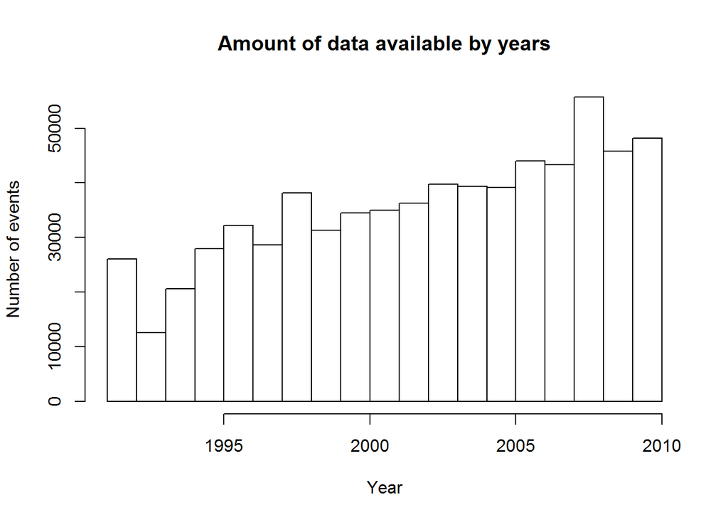

```r
if (!("storm" %in% ls())) { # it will reduce rmd compilation time
  storm <- read.csv("d.csv")
  #storm <- read.csv("repdata-data-StormData.csv")
}
storm$year <- format(as.Date(storm$BGN_DATE, format = "%m/%d/%Y %H:%M:%S"), "%Y")
# View(table(storm$year))
hist(as.numeric(storm$year),
  xlab="Year", ylab="Number of events", main="Amount of data available by years")
```

Then we prepare a subset of data with only those variables that we will use for the study:

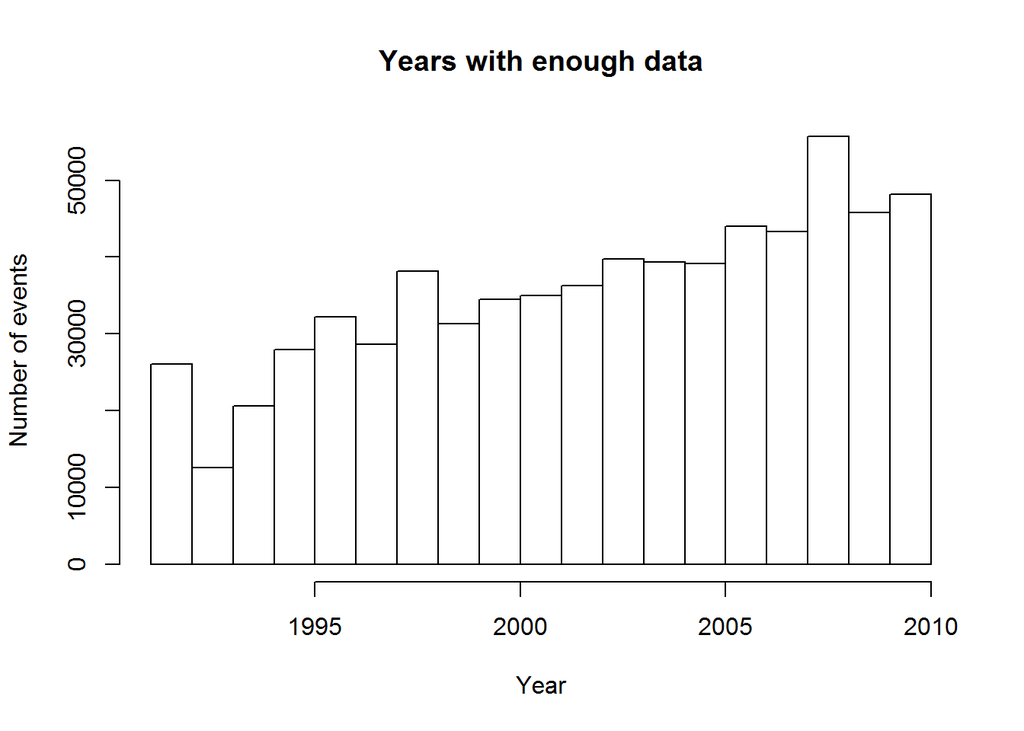

```r
d <- storm[storm$year>1990 & storm$year<2011,c("BGN_DATE", "EVTYPE","FATALITIES","INJURIES","PROPDMG","PROPDMGEXP","CROPDMG","CROPDMGEXP","year")]
hist(as.numeric(d$year),
  xlab="Year", ylab="Number of events", main="Years with enough data")
```

```r
#   write.table(d, "d.csv", sep=",", row.name=TRUE)
#   d <- read.csv("d.csv")
#   View(head(d))
```

Aggregate data for injuries and fatalities:

```r
fatalities <- ddply(d,~EVTYPE,summarise,t=sum(FATALITIES))
injuries <- ddply(d,~EVTYPE,summarise,t=sum(INJURIES))
fatalities <- tail(fatalities[order(fatalities$t),],10)
injuries <- tail(injuries[order(injuries$t),],10)
#View (fatalities)
```

### Most harmful to population health

You can see the types of events that appeared to be most harmful to population health in terms of fatalities:

```r
  kable(fatalities, format="markdown")
```

|  | EVTYPE | t |
| --- | --- | --- |
| 19 | AVALANCHE | 215 |
| 359 | HIGH WIND | 244 |
| 856 | TSTM WIND | 285 |
| 585 | RIP CURRENT | 339 |
| 170 | FLOOD | 412 |
| 464 | LIGHTNING | 790 |
| 275 | HEAT | 874 |
| 153 | FLASH FLOOD | 910 |
| 834 | TORNADO | 1112 |
| 130 | EXCESSIVE HEAT | 1867 |

You can see the types of events that appeared to be most harmful to population health in terms of injuries:

```r
  kable(injuries, format="markdown")
```

|  | EVTYPE | t |
| --- | --- | --- |
| 411 | HURRICANE/TYPHOON | 1275 |
| 972 | WINTER STORM | 1321 |
| 275 | HEAT | 1489 |
| 153 | FLASH FLOOD | 1747 |
| 427 | ICE STORM | 1975 |
| 856 | TSTM WIND | 4441 |
| 464 | LIGHTNING | 5036 |
| 130 | EXCESSIVE HEAT | 6387 |
| 170 | FLOOD | 6779 |
| 834 | TORNADO | 19334 |

### Most damaging events

Now let’s figure out types of events have the greatest economic consequences. The I calculated actual dollar amount for different types of damages. For this purpose I prepare manage multipliers:

```r
table(d$PROPDMGEXP)
```

```
##
##             -      ?      +      0      1      2      3      4      5
## 336583      1      8      5    215     25     13      4      4     28
##      6      7      8      B      h      H      K      m      M
##      4      5      1     35      1      6 333708      7   7967
```

```r
d$PROPDMGEXP <- sub("[-+?123456789H]","0", d$PROPDMGEXP, ignore.case=TRUE) # do not include "0" for replacement!
d$PROPDMGEXP <- sub("^$",  0, d$PROPDMGEXP, ignore.case=TRUE)
d$PROPDMGEXP <- sub("^B$", 9, d$PROPDMGEXP, ignore.case=TRUE)
d$PROPDMGEXP <- sub("^M$", 6, d$PROPDMGEXP, ignore.case=TRUE)
d$PROPDMGEXP <- sub("^K$", 3, d$PROPDMGEXP, ignore.case=TRUE)
#sum(d$PROPDMG)
#sum(d$PROPDMG * 10 ^ as.numeric(d$PROPDMGEXP))
d$PROPDMG <- d$PROPDMG * 10 ^ as.numeric(d$PROPDMGEXP)

table(d$CROPDMGEXP)
```

```
##
##             ?      0      2      B      k      K      m      M
## 456910      7     19      1      7     21 219786      1   1868
```

```r
d$CROPDMGEXP <- sub("[-+?123456789H]","0", d$CROPDMGEXP, ignore.case=TRUE) # do not include "0" for replacement!
d$CROPDMGEXP <- sub("^$",  0, d$CROPDMGEXP, ignore.case=TRUE)
d$CROPDMGEXP <- sub("^B$", 9, d$CROPDMGEXP, ignore.case=TRUE)
d$CROPDMGEXP <- sub("^M$", 6, d$CROPDMGEXP, ignore.case=TRUE)
d$CROPDMGEXP <- sub("^K$", 3, d$CROPDMGEXP, ignore.case=TRUE)
d$CROPDMG <- d$CROPDMG * 10 ^ as.numeric(d$CROPDMGEXP)

dam1 <- ddply(d,~EVTYPE,summarise,t=sum(PROPDMG)) ## Property damage
dam2 <- ddply(d,~EVTYPE,summarise,t=sum(CROPDMG)) ## Agricultural (crop) damage

dam1 <- tail(dam1[order(dam1$t),],10) # prop
dam2 <- tail(dam2[order(dam2$t),],10) # crop
#View (dam1)
```

You can see the types of events that caused most damange to property:

```r
  kable(dam1, format="markdown")
```

[output not shown]

You can see the types of events that caused most damange to crops:

```r
  kable(dam2, format="markdown")
```

|  | EVTYPE | t |
| --- | --- | --- |
| 212 | FROST/FREEZE | 1080676000 |
| 140 | EXTREME COLD | 1292973000 |
| 153 | FLASH FLOOD | 1332870100 |
| 411 | HURRICANE/TYPHOON | 2607872800 |
| 402 | HURRICANE | 2731410000 |
| 244 | HAIL | 2943620473 |
| 427 | ICE STORM | 5022033500 |
| 590 | RIVER FLOOD | 5029459000 |
| 170 | FLOOD | 5507096450 |
| 95 | DROUGHT | 13941292000 |

# Results

Events that cause most fatalities are: **EXCESSIVE HEAT**, TORNADO and FLASH FLOOD.  
The most causing injuries event is: **TORNADO**.  
Events that cause most economical damage are: **FLOOD**, HURRICANE/TYPHOON and STORM SURGE.